# 第06回 事前学習

作者

J22069 野倉悠正

公開

2026年5月26日

# 1 坂城町講座までのロードマップ

- 基本情報決定（日時・場所・テーマなど）
- 指導案の作成
- ポスター作成 👈 今回
- 信州おまつりナビからのシステムの移植・構築 👈 今回
- 教材スライドの作成
- ロールプレイング（5/29 > 6月上旬 に変更）
- ロープレで見つかった改善策の反映と微修正
- **教室当日！**

# 2 ポスター作成

竹内さんにポスターの素案をもらい、ポスターを作成した。

竹内さんの素案(AI使用)

[figure not shown]

完成版

[figure not shown]

[video not shown]

# 3 Viteを用いたReact環境の構築

[figure not shown]

[Vite（ヴィート）](https://ja.vite.dev/)とは、現代の現代のフロントエンド開発向けに設計された超高速なビルドツール。フランス語で「速い」を意味し、アプリケーションの規模に関わらず一瞬でサーバーが立ち上がる。

信州おまつりナビでは、従来までのCreate React Appを使用していたが、開発後半にはサーバーの起動に時間がかかり、少々不便を感じていた。

```
bash
```

```bash
npm create vite@latest sakaki-map
```

上のコマンドでViteでの環境セットアップを開始。

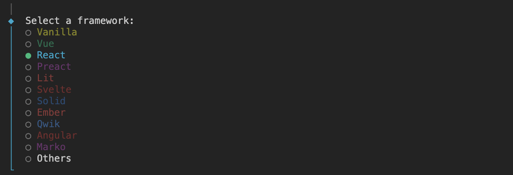

初期設定になり、フレームワークを聞かれるので、**React**を選ぶ。

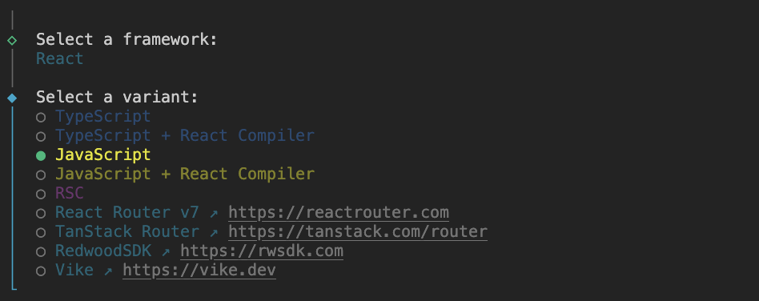

次に言語が聞かれるので、**JavaScript**を選ぶ。

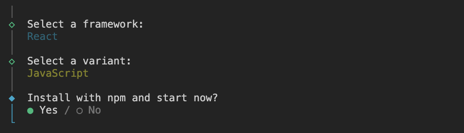

このままパッケージをインストールしてサーバーを立ち上げるかどうか聞かれるので、**Yes**を選ぶ。

# 4 信州おまつりナビからのシステム移植

信州おまつりナビから、`App.js`と`Map.js`を移植した。Viteでは高速処理の都合上`.jsx`のファイルのみが実行されるようになっているが、`.js`の拡張子を変更するだけでOK。

**ノートJSとJSXの違い**

JSは「普通のJavaScript」、JSXは「JavaScriptの中にHTMLみたいなタグを直接書けるようにした特別な書き方」の違いである。

**ヒントViteで`.jsx`ファイルを使わないといけない理由は？**

Viteは開発サーバーの裏側で`esbuild`という超高速なツールを使ってコードを変換している。この`esbuild`は、スピードを極限まで上げるために「ファイルの中身をわざわざ読んで、JSXが書かれているかチェックする」という時間のかかるようなことはしない。 **「拡張子が`.jsx`や`.tsx`ならJSXとして処理し、`.js`なら普通のJavaScriptとして処理する」**という厳密なルールで動いているのが、`.jsx`ファイルを使わないといけない理由である。

## 4.1 インポートして不要機能を削除し最適化したファイル

```
App.js
```

```javascript
import React from 'react';
import { MantineProvider, AppShell, Group, Title, ColorSchemeScript } from '@mantine/core';
import Map from './components/Map';
import '@mantine/core/styles.css';
import './css/App.css';

// ワークショップ用のシンプルなテーマ設定
const theme = {
  primaryColor: 'blue',
  defaultRadius: 'md',
};

export default function App() {
  return (
    <MantineProvider theme={theme} defaultColorScheme="dark">
      {/* 画面全体のレイアウト構造 */}
      <AppShell header={{ height: 60 }}>

        {/* ヘッダー：タイトルを表示 */}
        <AppShell.Header p="xs">
          <Group h="100%" px="md">
            <Title order={3} c="blue">さかき思い出マップ</Title>
          </Group>
        </AppShell.Header>

        {/* メインエリア：ここに地図が表示される */}
        <AppShell.Main p={0}>
          <Map />
        </AppShell.Main>

      </AppShell>
    </MantineProvider>
  );
}
```

```
Map.js
```

```javascript
import React, { useState, useEffect, useMemo, useRef } from 'react';
import { renderToString } from 'react-dom/server';
import { MapContainer, TileLayer, Marker, Popup, useMap } from 'react-leaflet';
import { Text, Button, Group, Paper, Title, List, ScrollArea, TextInput, Stack, Divider, Box, CloseButton, ActionIcon } from '@mantine/core';
import { useMediaQuery, useElementSize } from '@mantine/hooks';
import { IconCurrentLocation, IconMapPinFilled, IconSearch, IconCar, IconTrain, IconPlus, IconMinus, IconUpload, IconMap, IconWorld } from '@tabler/icons-react';
import L from 'leaflet';
import { MapData } from '../seed/MapData';
import 'leaflet/dist/leaflet.css';
import '../css/GlassStyle.css';
// 生徒用の編集ファイルの読み込み
import { textColor, pinColor, textSize, fontFamily } from '../lv1';
import { useSatellite, useCurrentButton, useDetailCard, useUploadPage } from '../lv2';

// 初期位置（全地点の中央を計算）
const calculateCenter = (data) => {
  const validData = data.filter(d => d.latitude && d.longitude);
  if (validData.length === 0) return [36.4632, 138.1834]; // データがない場合のデフォルト
  const lats = validData.map(d => d.latitude);
  const lngs = validData.map(d => d.longitude);
  const midLat = (Math.max(...lats) + Math.min(...lats)) / 2;
  const midLng = (Math.max(...lngs) + Math.min(...lngs)) / 2;
  return [midLat, midLng];
};
const INITIAL_CENTER = calculateCenter(MapData);

// 【Lv.1】設定したpinColorを反映するカスタムピン
const customPinIcon = L.divIcon({
  className: 'custom-pin',
  html: renderToString(
    <div style={{
      position: 'relative', width: '32px', height: '32px',
      filter: 'drop-shadow(1.5px 1.5px 0 white) drop-shadow(-1.5px -1.5px 0 white) drop-shadow(-1.5px 1.5px 0 white) drop-shadow(1.5px -1.5px 0 white) drop-shadow(0px 3px 5px rgba(0,0,0,0.5))'
    }}>
      {/* ベース色 */}
      <IconMapPinFilled size={32} color={pinColor} style={{ position: 'absolute', top: 0, left: 0 }} />
      {/* 黒の半透明グラデーション（影）を重ねる */}
      <IconMapPinFilled size={32} color="url(#black-gradient)" style={{ position: 'absolute', top: 0, left: 0 }} />
    </div>
  ),
  iconSize: [32, 32],
  iconAnchor: [16, 32],
  popupAnchor: [0, -32],
});

const userIcon = L.divIcon({
  className: 'user-location-marker',
  html: '<div class="pulse"></div><div class="dot"></div>',
  iconSize: [20, 20],
  iconAnchor: [10, 10],
  popupAnchor: [0, -10]
});

// === マップ移動コンポーネント ===
function MapRecenter({ center }) {
  const map = useMap();
  useEffect(() => { if (center) map.flyTo(center, 14, { duration: 2.5 }); }, [center, map]);
  return null;
}

// === 要素の中央に移動するコンポーネント ===
function MapBoundsHandler({ points, sidebarWidth, sidebarHeight, isMobile }) {
  const map = useMap();
  useEffect(() => {
    if (!points || points.length === 0) return;
    try {
      const bounds = L.latLngBounds(points);
      const paddingOptions = isMobile
        ? { paddingTopLeft: [40, 100], paddingBottomRight: [40, sidebarHeight + 40] }
        : { paddingTopLeft: [sidebarWidth + 40, 100], paddingBottomRight: [40, 40 ] };
      map.flyToBounds(bounds, { ...paddingOptions, animate: true, duration: 1.5, maxZoom: 15 });
    } catch (e) { console.error(e); }
  }, [points, map, sidebarWidth, sidebarHeight, isMobile]);
  return null;
}

function ResizeMap({ sidebarHeight, isResizing }) {
  const map = useMap();
  useEffect(() => {
    map.invalidateSize();
    if (!isResizing) {
      const timer = setTimeout(() => map.invalidateSize(), 300);
      return () => clearTimeout(timer);
    }
  }, [sidebarHeight, isResizing, map]);
  return null;
}

// === マップコントロール（拡大縮小・現在地・レイヤー）===
function MapControls({ handleCurrentLocation, isLocationActive, mapLayer, setMapLayer, isLocating }) {
  const map = useMap();

  const toggleLayer = () => {
    if (mapLayer === 'normal') setMapLayer('satellite');
    else setMapLayer('normal');
  };

  return (
    <Stack gap="xs">
      <Paper className="glass-map-control" style={{ display: 'flex', flexDirection: 'column' }}>
        <ActionIcon onClick={() => map.zoomIn()} size="lg" variant="subtle" style={{ borderRadius: 0, borderBottom: '1px solid rgba(128,128,128,0.2)' }} color="gray"><IconPlus size={18} /></ActionIcon>
        <ActionIcon onClick={() => map.zoomOut()} size="lg" variant="subtle" style={{ borderRadius: 0 }} color="gray"><IconMinus size={18} /></ActionIcon>
      </Paper>

      {/* 【Lv.2】自作レイヤー切り替えボタン */}
      {useSatellite && (
        <Paper className="glass-map-control">
          <ActionIcon onClick={toggleLayer} size="lg" variant="subtle" color="gray">
            {mapLayer === 'satellite' ? <IconMap size={18} /> : <IconWorld size={18} />}
          </ActionIcon>
        </Paper>
      )}

      {/* 【Lv.2】現在地ボタンの表示切り替え */}
      {useCurrentButton && (
        <Paper className="glass-map-control">
          <ActionIcon loading={isLocating} onClick={handleCurrentLocation} size="lg" variant={isLocationActive ? "filled" : "subtle"} color={isLocationActive ? "blue" : "gray"}>
            <IconCurrentLocation size={18} />
          </ActionIcon>
        </Paper>
      )}
    </Stack>
  );
}

// === ユーティリティ関数 ===
const calculateDistance = (lat1, lon1, lat2, lon2) => {
  const R = 6371;
  const dLat = (lat2 - lat1) * Math.PI / 180;
  const dLon = (lon2 - lon1) * Math.PI / 180;
  const a = Math.sin(dLat / 2) ** 2 + Math.cos(lat1 * Math.PI / 180) * Math.cos(lat2 * Math.PI / 180) * Math.sin(dLon / 2) ** 2;
  return R * 2 * Math.atan2(Math.sqrt(a), Math.sqrt(1 - a));
};

// === メインコンポーネント ===
function Map() {
  const isMobile = useMediaQuery('(max-width: 768px)');

  const memories = MapData; // さかきマップ用に変数を読み替え
  const validMemories = useMemo(() => memories.filter(f => f.latitude && f.longitude), [memories]);

  const [mapCenter, setMapCenter] = useState(null);
  const [userLocation, setUserLocation] = useState(null);
  const [isLocationActive, setIsLocationActive] = useState(false);
  const [isLocating, setIsLocating] = useState(false);
  const [fitPoints, setFitPoints] = useState(null);
  const [searchTerm, setSearchTerm] = useState('');
  const [selectedMemoryId, setSelectedMemoryId] = useState(null);
  const [isResizing, setIsResizing] = useState(false);
  const [mapLayer, setMapLayer] = useState('normal'); // normal, satellite
  const [sidebarWidth] = useState(350);
```

```javascript
  const { ref: sidebarRef } = useElementSize();
  const { ref: titleOnlyRef, height: titleOnlyHeight } = useElementSize();
  const { ref: cardRef, height: cardHeight } = useElementSize();

  const markerRefs = useRef({});

  // 【Lv.1】設定したテキストスタイルを一括管理
  const customTextStyle = {
    color: textColor,
    fontSize: `${textSize}px`,
    fontFamily: fontFamily
  };

  const filteredMemories = useMemo(() => {
    const q = searchTerm.toLowerCase();
    return validMemories.filter(f => f.name?.toLowerCase().includes(q) || f.location?.toLowerCase().includes(q));
  }, [validMemories, searchTerm]);

  const selectedMemory = useMemo(() =>
    validMemories.find(f => f.id === selectedMemoryId),
  [validMemories, selectedMemoryId]);

  const layerUrl = useMemo(() => {
    if (mapLayer === 'satellite') return "https://mt1.google.com/vt/lyrs=y&hl=ja&x={x}&y={y}&z={z}";
    return "https://mt1.google.com/vt/lyrs=m&hl=ja&x={x}&y={y}&z={z}";
  }, [mapLayer]);

  const snapPoints = useMemo(() => {
    const handleH = 32;
    const minH = titleOnlyHeight + handleH + 16;
    const selectedH = (selectedMemoryId ? titleOnlyHeight + handleH + cardHeight + 68 : 0);
    const midH = titleOnlyHeight + handleH + (isMobile ? 120 : 400);
    const maxH = window.innerHeight * 0.92;
    return [minH, selectedH, midH, maxH];
  }, [titleOnlyHeight, cardHeight, selectedMemoryId, isMobile]);

  const [sidebarHeight, setSidebarHeight] = useState(window.innerHeight * 0.45);

  useEffect(() => {
    if (validMemories.length > 0 && !fitPoints && !selectedMemoryId) {
      setFitPoints(validMemories.map(f => [f.latitude, f.longitude]));
    }
  }, [validMemories, fitPoints, selectedMemoryId]);

  useEffect(() => {
    if (titleOnlyHeight > 0 && sidebarHeight === window.innerHeight * 0.45) {
      setSidebarHeight(snapPoints[2]);
    }
  }, [titleOnlyHeight, snapPoints, sidebarHeight]);

  useEffect(() => {
    if (selectedMemoryId) {
      const targetMidH = snapPoints[1];
      if (sidebarHeight < targetMidH) setSidebarHeight(targetMidH);
    }
  }, [selectedMemoryId, snapPoints]);

  useEffect(() => {
    if (selectedMemoryId && markerRefs.current[selectedMemoryId]) {
      Object.keys(markerRefs.current).forEach(id => {
        if (parseInt(id, 10) !== selectedMemoryId) markerRefs.current[id]?.closePopup();
      });
      markerRefs.current[selectedMemoryId].openPopup();
    }
  }, [selectedMemoryId, filteredMemories]);

  const handleReset = () => {
    setSelectedMemoryId(null);
    setMapCenter(null);
    setFitPoints(validMemories.map(f => [f.latitude, f.longitude]));
    validMemories.forEach(f => markerRefs.current[f.id]?.closePopup());
    setIsLocationActive(false);
  };

  const handleCurrentLocation = () => {
    if (isLocationActive) {
      // すでに現在地にズームしている場合は、解除して全体表示に戻す
      setIsLocationActive(false);
      setFitPoints(validMemories.map(f => [f.latitude, f.longitude]));
    } else {
      // それ以外（初めて押す or 解除後に再度押す）の場合は、必ず最新の現在地を再取得する
      setIsLocating(true);
      navigator.geolocation.getCurrentPosition(
        p => {
          const loc = [p.coords.latitude, p.coords.longitude];
          setUserLocation(loc);
          setIsLocationActive(true);
          setFitPoints([...validMemories.map(f => [f.latitude, f.longitude]), loc]);
          setIsLocating(false);
        },
        error => {
          console.error(error);
          alert('現在地の取得に失敗しました。端末やブラウザの位置情報許可設定を確認してください。');
          setIsLocating(false);
        },
        { enableHighAccuracy: true, timeout: 10000, maximumAge: 0 }
      );
    }
  };

  const startResizing = (e) => { e.preventDefault(); setIsResizing(true); };

  useEffect(() => {
    const handleMove = (e) => {
      if (!isResizing) return;
      const clientY = e.touches ? e.touches[0].clientY : e.clientY;
      setSidebarHeight(Math.max(60, Math.min(window.innerHeight - clientY, window.innerHeight * 0.95)));
    };
    const stopResizing = () => {
      if (!isResizing) return;
      setIsResizing(false);
      const closest = snapPoints.reduce((prev, curr) =>
        (Math.abs(curr - sidebarHeight) < Math.abs(prev - sidebarHeight) ? curr : prev)
      );
      setSidebarHeight(closest);
    };
    if (isResizing) {
      window.addEventListener('mousemove', handleMove);
      window.addEventListener('mouseup', stopResizing);
      window.addEventListener('touchmove', handleMove, { passive: false });
      window.addEventListener('touchend', stopResizing);
    }
    return () => {
      window.removeEventListener('mousemove', handleMove);
      window.removeEventListener('mouseup', stopResizing);
      window.removeEventListener('touchmove', handleMove);
      window.removeEventListener('touchend', stopResizing);
    };
  }, [isResizing, sidebarHeight, snapPoints]);

  return (
    <Box
      className="festival-map-container"
      style={{
        position: 'absolute', top: 60, left: 0, right: 0, bottom: 0,
        overflow: 'hidden', display: 'flex', flexDirection: 'column',
        backgroundColor: '#1A1B1E', touchAction: 'none'
      }}
    >
      {/* アイコン用のグラデーション定義 */}
      <svg width="0" height="0" style={{ position: 'absolute' }}>
        <defs>
          <linearGradient id="black-gradient" x1="0%" y1="0%" x2="0%" y2="100%">
            <stop offset="0%" stopColor="rgba(0,0,0,0)" /> {/* 上は透明 */}
            <stop offset="100%" stopColor="rgba(0,0,0,0.2)" /> {/* 下は透明度95%(不透明度5%)の黒 */}
          </linearGradient>
        </defs>
      </svg>

      <style>
        {`
          body { overflow: hidden; position: fixed; width: 100%; }
          .user-location-marker .dot { width: 12px; height: 12px; background-color: #228be6; border: 2px solid white; border-radius: 50%; position: absolute; top: 4px; left: 4px; z-index: 2; }
          .user-location-marker .pulse { width: 20px; height: 20px; background-color: rgba(34, 139, 230, 0.6); border-radius: 50%; position: absolute; top: 0; left: 0; animation: pulse-animation 2s infinite; }
          @keyframes pulse-animation { 0% { transform: scale(0.5); opacity: 1; } 100% { transform: scale(3); opacity: 0; } }
          .leaflet-popup-close-button { display: none !important; }
          .sidebar-transition { transition: height 0.3s cubic-bezier(0.2, 0.8, 0.2, 1); }
          .controls-transition { transition: bottom 0.3s cubic-bezier(0.2, 0.8, 0.2, 1); }
          .fade-transition { transition: opacity 0.2s ease, transform 0.2s ease; }
          .leaflet-container { z-index: 1 !important; height: 100% !important; width: 100% !important; }
        `}
      </style>
```

```javascript
      <Box style={{ flex: 1, position: 'relative', width: '100%', height: '100%' }}>
        <MapContainer center={INITIAL_CENTER} zoom={13} zoomControl={false} attributionControl={false} style={{ height: '100%', width: '100%' }}>

          <TileLayer
            attribution='© Google'
            url={useSatellite ? layerUrl : "https://mt1.google.com/vt/lyrs=m&hl=ja&x={x}&y={y}&z={z}"}
          />

          <div className={!isResizing ? 'controls-transition' : ''} style={{ position: 'absolute', bottom: isMobile ? (sidebarHeight + 20) : 20, right: 20, zIndex: 1000 }}>
            <MapControls isLocationActive={isLocationActive} isLocating={isLocating} handleCurrentLocation={handleCurrentLocation} mapLayer={mapLayer} setMapLayer={setMapLayer} />
          </div>

          <MapRecenter center={mapCenter} />
          <MapBoundsHandler points={fitPoints} sidebarWidth={sidebarWidth} sidebarHeight={sidebarHeight} isMobile={isMobile} />
          <ResizeMap sidebarHeight={sidebarHeight} isResizing={isResizing} />

          {filteredMemories.map(f => (
            <Marker
              key={f.id} position={[f.latitude, f.longitude]}
              icon={customPinIcon}
              ref={el => (markerRefs.current[f.id] = el)}
              eventHandlers={{
                mouseover: (e) => e.target.openPopup(),
                mouseout: (e) => { if (selectedMemoryId !== f.id) e.target.closePopup(); },
                click: (e) => {
                  setSelectedMemoryId(f.id);
                  const map = e.target._map;
                  const offset = isMobile ? [0, -sidebarHeight / 3 + 30] : [sidebarWidth / 2, 30];
                  const targetCenter = map.unproject(map.project([f.latitude, f.longitude], 14).subtract(offset), 14);
                  map.flyTo(targetCenter, 14, { animate: true, duration: 2.0 });
                }
              }}
            >
              <Popup closeOnClick={false} autoClose={false}>
                <Box style={{ minWidth: '140px' }}>
                  <Group justify="space-between" wrap="nowrap" mb={4}>
                    {/* 【Lv.1】文字スタイル連動 */}
                    <Text style={customTextStyle} fw={700}>{f.name}</Text>
                    <CloseButton size="xs" onClick={(e) => { e.stopPropagation(); handleReset(); }} />
                  </Group>
                </Box>
              </Popup>
            </Marker>
          ))}
          {userLocation && <Marker position={userLocation} icon={userIcon}><Popup>現在地</Popup></Marker>}
        </MapContainer>
      </Box>

      {/* サイドバー本体（スマホ対応の動きを維持） */}
      <Box ref={sidebarRef} className={`glass-sidebar ${!isResizing ? 'sidebar-transition' : ''}`} style={{
        position: 'absolute', bottom: '0',
        left: isMobile ? '10px' : '20px', right: isMobile ? '10px' : 'auto',
        width: isMobile ? 'auto' : `${sidebarWidth}px`, height: `${sidebarHeight}px`,
        borderRadius: '12px 12px 0 0', touchAction: 'none',
        display: 'flex', flexDirection: 'column', zIndex: 1000, overflow: 'hidden'
      }}>
        <Box onMouseDown={startResizing} onTouchStart={startResizing} style={{ height: '32px', paddingTop: '12px', cursor: 'row-resize', display: 'flex', justifyContent: 'center', alignItems: 'flex-start', touchAction: 'none' }}>
          <Box style={{ width: '40px', height: '5px', borderRadius: '10px', backgroundColor: 'rgba(128,128,128,0.4)' }} />
        </Box>

        <Box px="md" pb="md" style={{ borderBottom: sidebarHeight > snapPoints[0] + 10 ? '1px solid #373a40' : 'none', touchAction: 'none' }}>
          <div ref={titleOnlyRef}>
            <Title order={3} style={{ ...customTextStyle, color: 'white' }} mb={sidebarHeight > snapPoints[0] + 10 ? "xs" : 0}>
              思い出の場所一覧
            </Title>
          </div>

          <div className="fade-transition" style={{ opacity: sidebarHeight > snapPoints[0] + 10 ? 1 : 0, pointerEvents: sidebarHeight > snapPoints[0] + 10 ? 'all' : 'none', height: sidebarHeight > snapPoints[0] + 10 ? 'auto' : 0, overflow: 'hidden' }}>
            <Stack gap="xs">
              <TextInput placeholder="検索..." leftSection={<IconSearch size={14} />} value={searchTerm} onChange={(e) => setSearchTerm(e.currentTarget.value)} size="xs" />

              {/* 【Lv.2】隠しアップロードページの解放 */}
              {useUploadPage && (
                 <Button color="cyan" leftSection={<IconUpload size={18} />} fullWidth onClick={() => alert('送信モーダルを開く（Lv.4の実装）')}>
                   データを母艦へ送信🚀
                 </Button>
              )}

              {/* 【Lv.2】詳細カードの解放 */}
              {useDetailCard && selectedMemory && (
                <div ref={cardRef} className="fade-transition">
                  <Paper shadow="sm" p="md" withBorder className="glass-map-control" style={{ position: 'relative' }}>
                    <CloseButton onClick={handleReset} style={{ position: 'absolute', top: 8, right: 8, zIndex: 2 }} />
                    <Stack gap="xs">
                      <Box pr={30}>
                        <Text style={{ ...customTextStyle, color: 'white' }} fw={700}>{selectedMemory.name}</Text>
                        <Text size="xs" c="dimmed">{selectedMemory.location}</Text>
                        {userLocation && <Text size="xs" c="blue.5" fw={600} mt={4}>現在地から約 {calculateDistance(userLocation[0], userLocation[1], selectedMemory.latitude, selectedMemory.longitude).toFixed(1)} km</Text>}
                      </Box>
                      <Divider my="sm" label="ルートを検索" labelPosition="center" />
                      <Group grow gap="xs">
                        <Button size="xs" color="blue" leftSection={<IconCar size={14} />} onClick={() => {
                          const originParam = userLocation ? `&origin=${userLocation[0]},${userLocation[1]}` : '';
                          window.open(`https://www.google.com/maps/dir/?api=1${originParam}&destination=${selectedMemory.latitude},${selectedMemory.longitude}&travelmode=driving`, '_blank');
                        }}>車</Button>
                        <Button size="xs" color="teal" leftSection={<IconTrain size={14} />} onClick={() => {
                          const originParam = userLocation ? `&origin=${userLocation[0]},${userLocation[1]}` : '';
                          window.open(`https://www.google.com/maps/dir/?api=1${originParam}&destination=${selectedMemory.latitude},${selectedMemory.longitude}&travelmode=transit`, '_blank');
                        }}>電車</Button>
                      </Group>
                    </Stack>
                  </Paper>
                </div>
              )}
            </Stack>
          </div>
        </Box>
```

```javascript
        <ScrollArea style={{ flex: 1, opacity: sidebarHeight > snapPoints[0] + 20 ? 1 : 0, touchAction: 'pan-y' }}>
          <Stack gap="xs" pt="md" pb={80} pl={0} pr="md">
            <List spacing={0} size="sm">
              {filteredMemories.map(f => (
                <List.Item
                  key={f.id}
                  style={{
                    cursor: 'pointer', padding: '12px 16px', borderRadius: '0 8px 8px 0',
                    backgroundColor: selectedMemoryId === f.id ? 'rgba(34, 139, 230, 0.15)' : 'transparent',
                    borderBottom: '1px solid rgba(255,255,255,0.05)'
                  }}
                  onClick={() => {
                    setSelectedMemoryId(f.id);
                    setFitPoints(userLocation ? [[f.latitude, f.longitude], userLocation] : [[f.latitude, f.longitude]]);
                  }}
                >
                  <Group justify="space-between" wrap="nowrap">
                    <Box>
                      {/* 【Lv.1】文字スタイル連動 */}
                      <Text style={{ ...customTextStyle, color: 'white' }} fw={500}>{f.name}</Text>
                      <Text c="dimmed" size="xs">{f.location}</Text>
                    </Box>
                    {/* 【Lv.1】ピン色連動 */}
                    <Box style={{ position: 'relative', width: 16, height: 16, flexShrink: 0 }}>
                      <IconMapPinFilled size={16} color={pinColor} style={{ position: 'absolute', top: 0, left: 0 }} />
                      <IconMapPinFilled size={16} color="url(#black-gradient)" style={{ position: 'absolute', top: 0, left: 0 }} />
                    </Box>
                  </Group>
                </List.Item>
              ))}
            </List>
          </Stack>
        </ScrollArea>
      </Box>
    </Box>
  );
}

export default Map;
```